# 表达矩阵分析大全

Note : Please **don’t use it** if you are not the fan of our [biotrainee](http://www.bio-info-trainee.com/), Thanks.

### 来龙去脉

GEO数据库挖掘系列知识分享课程，于2016年首发于生信菜鸟团博客：http://www.bio-info-trainee.com/2087.html

配套教学视频在B站：https://www.bilibili.com/video/av26731585/

早期目录如下：

- 第一讲：GEO，表达芯片与R
- 第二讲：从GEO下载数据得到表达量矩阵
- 第三讲：对表达量矩阵用GSEA软件做分析
- 第四讲：根据分组信息做差异分析
- 第五讲：对差异基因结果做GO/KEGG超几何分布检验富集分析
- 第六讲：指定基因分组boxplot指定基因list画热图
- 第七讲：根据差异基因list获取string数据库的PPI网络数据
- 第八讲：PPI网络数据用R或者cytoscape画网络图
- 第九讲：网络图的子网络获取
- 第十讲：hug genes如何找

### 2018年更新版

2018是一个特殊的年份，我们生信技能树落地了很多线下分享会，作为创始人我身先士卒准备了非常多的干货教程，在B站免费分享 74小时的生物信息学系列视频课程： 1.3个学生的linux视频学习笔记

2.生信人应该这样学R语言系列视频学习心得笔记分享

5.公共数据库挖掘视频学习心得体会

6.生信小技巧系列第一季完结版视频教程学习笔记分享

本项目主要是GEO数据库挖掘课程的代码仓库，记住，下面的每个文件夹都值得你拿出**50个小时以上的时间**来学习。

### 仓库概括

主要项目代码文件夹：

- GSE42872_main，主要演示GEO数据库挖掘的标准6步骤
- GSE11121_surivival，主要演示基于基因表达量分组的批量生存分析

六个任务项目文件夹：

- task1-check-specific-genes ， 主要演示检查自己感兴趣的基因在多个GSE数据集表现情况
- task2-lncRNA-mRNA-network ， 主要演示如何构建网络
- task3-multiple-groups ， 主要演示，如果样本分组信息非常复杂该如何进行下游分析
- task4-NPC， 主要演示GEO数据库挖掘的标准6步骤，跟GSE42872_main类似
- task5-dynamic-network-biomarker，主要演示新的算法，超脱于GSE42872_main展示的GEO数据库挖掘的标准6步骤
- task6-GEO-TCGA，主要演示如何结合TCGA数据库

两个额外补充项目文件夹：

- airway_RNAseq，主要演示如果是RNA-seq得到的表达矩阵该如何分析，与传统芯片表达矩阵的异同
- breast_cancer_meta-analysis ， 主要演示如何进行meta分析。

下面是主要代码文件夹 `GSE42872_main` 代码的展示：

### Then run step1 : download data

数据是灵魂！

It always not very easy to download data if you are in China, so I also upload the file `GSE42872_raw_exprSet.Rdata` , you can load it directly.

```r
if(F){
  library(GEOquery)
  gset <- getGEO('GSE42872', destdir=".",
                 AnnotGPL = F,
                 getGPL = F)
  save(gset,'GSE42872.gset.Rdata')
}
load('GSE42872_eSet.Rdata')
b = eSet[[1]] # 看清楚，某些GSE数据集有多个平台，注意挑选
raw_exprSet=exprs(b)
group_list=c(rep('control',3),rep('case',3))
save(raw_exprSet,group_list,
     file='GSE42872_raw_exprSet.Rdata')
```

### Then step2: check the expression matrix

高质量的数据是保障！

Try to understand my codes, how did I filter the probes by the annotation of each microarry, and how I check the group information for the different samples in each experiment.

Including PCA and Cluster figures, as below:

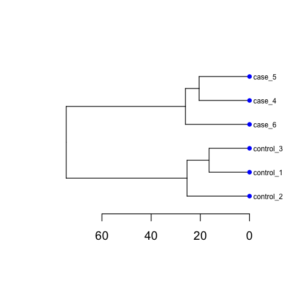

Cluster

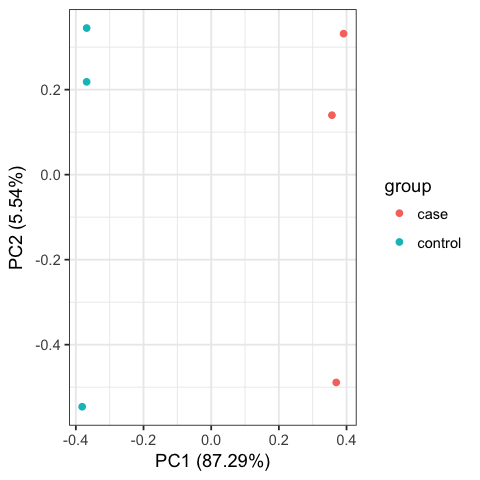

PCA

Please ensure that you do run those codes by yourself !!!

### Then step3: do DEG analysis

差异分析是核心流程

Normally we will do differential expression analysis for the microarray, and LIMMA is one of the best method, so I just use it. If the expression matrix(raw counts ) comes from mRNA-seq, you can also choose DESeq based on negative binomial (NB) distributions or baySeq and EBSeq.

Once DEG finished, we can choose top N genes for heatmap as below:

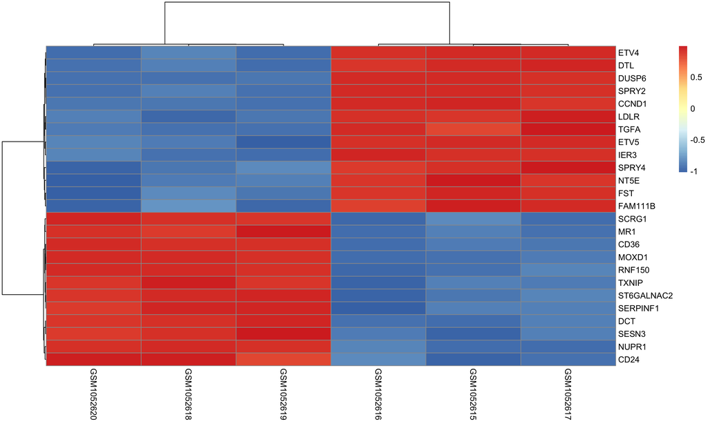

heatmap

and volcano plot as below:

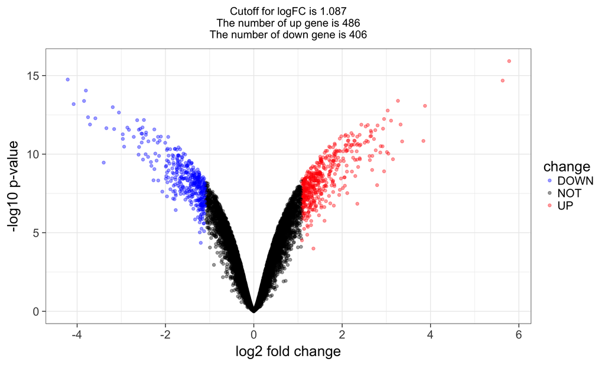

### Then step4 : annotation for GO and KEGG database

数据库的注释是升华！

Annotation for the significantly changed genes, over-representation test or GSEA for GO/KEGG/biocarta/rectome/MsigDB and so on.

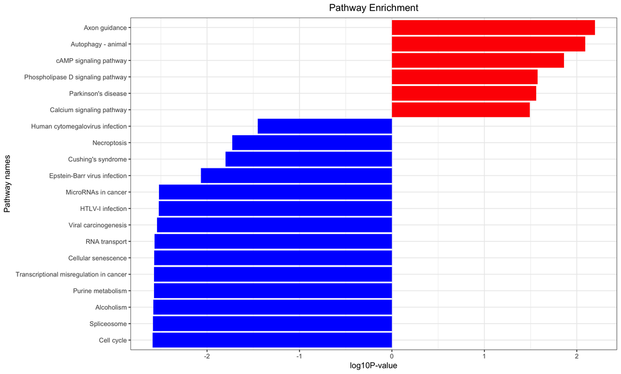

KEGG_GSEA

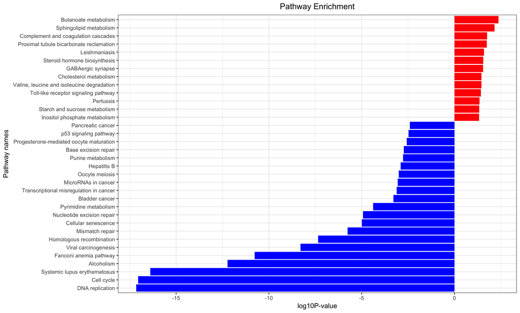

KEGG-enrichment

### Step5: survival analysis

生存分析是补充，只有样本量足够，而且样本的临床信息足够才能做这样的分析。

KM and cox ，需要掌握统计学原理。

### Step6: GSEA for Molecular Signatures Database (MSigDB)

算法是亮点，代码见文件夹

### Step7: GSVA for Molecular Signatures Database (MSigDB)

算法是门槛，代码见文件夹

### The videos tutorials :

All the videos are uploaded in YouTube: https://www.youtube.com/channel/UC67sImqK7V8tSWHMG8azIVA/videos

如果你在中国，你可能会喜欢B站： https://www.bilibili.com/read/cv719181 ，视频链接： https://www.bilibili.com/video/av26731585/

### 番外

其实不止是针对转录组表达芯片的数据分析教材，还有转录组数据处理流程，希望你可以仔细看，还有批量生存分析等各种其它统计分析方法我也会慢慢添加。

主要是根据大家的需求啦，希望大家多多反馈和提问哈！

### 最重要的是：

如果你觉得我的教程对你有帮助，请赞赏一杯咖啡哦！

如果你的赞赏超过了50元，请在扫描赞赏的同时留下你的邮箱地址，我会发送给你一个惊喜哦！

[figure not shown]

### 广告时间

关于我们

- 我的博客：生信菜鸟团 http://www.bio-info-trainee.com/
- 我们的论坛：生信技能树 http://www.biotrainee.com/thread-1376-1-1.html
- 我们的VIP社区：https://vip.biotrainee.com/d/311-
- 我们的微信公众号: https://mp.weixin.qq.com/s/egAnRfr3etccU_RsN-zIlg
- 我们的知识星球: https://t.zsxq.com/VjmQZNn
- 我们的腾讯课堂： https://biotree.ke.qq.com/
- 请善用搜索功能：http://weixin.sogou.com/
- 发邮件向我反馈 jmzeng1314@163.com